# Lab – EDA2

Shaobo Li

September 17, 2019

# Overview

In this lab, we introduce `ggplot` package for data visualization. It is a very powerful tool, although as a beginner, we only study some basic plots such as histogram, scatter plot, bar plot.

- **Histogram**: shows distribution of **a numeric variable**;
- **Scatter plot**: shows relationship between **two numeric variables**;
- **Bar plot**: shows distribution of **a categorical variable**.

```r
library(tidyverse)
```

As always, we need to set the correct working directory, the folder where your data are located. Below is the path of my working directory. You should modify it accordingly. Then we load the data. We will use the movie data for this lab.

```r
# set working directory (modify the path accordingly)
setwd("C:/Users/s674l142/Dropbox/Teaching/KU/data")
# load data
movie<- read_csv("movie.csv")
```

# R basic plot

We may start from R basic plot, which is less flexible comparing to `ggplot`.

## histogram for individual variables

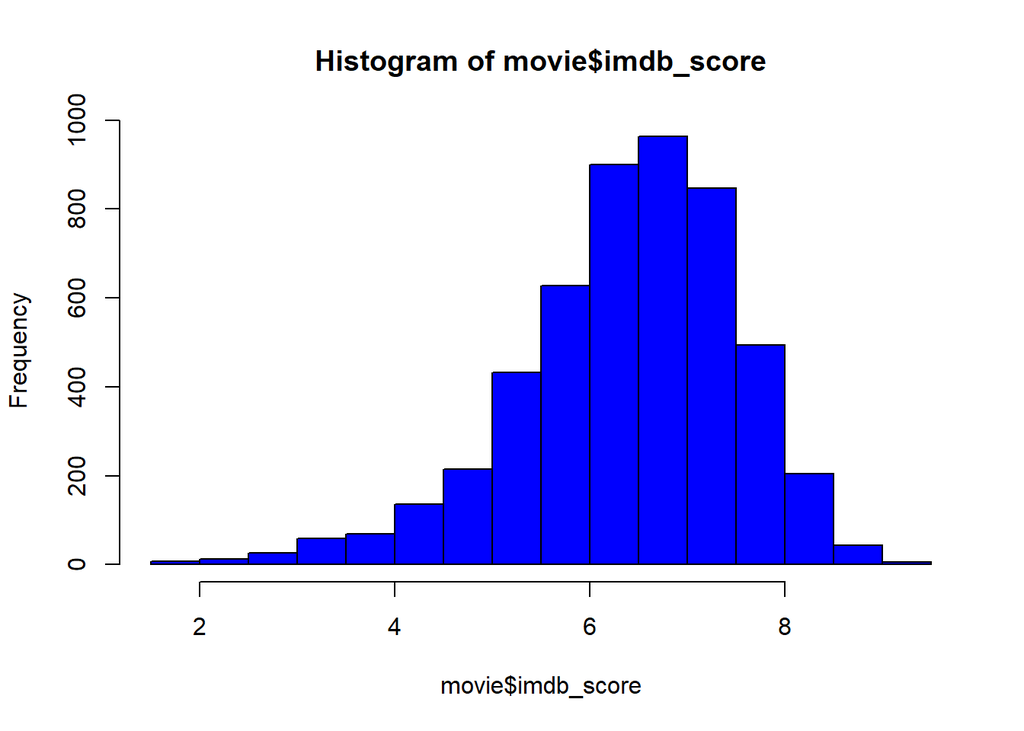

```r
hist(movie$imdb_score, col = "blue")
```

We can use the option below to set the window to display two figures (arranged in 1 row 2 columns).

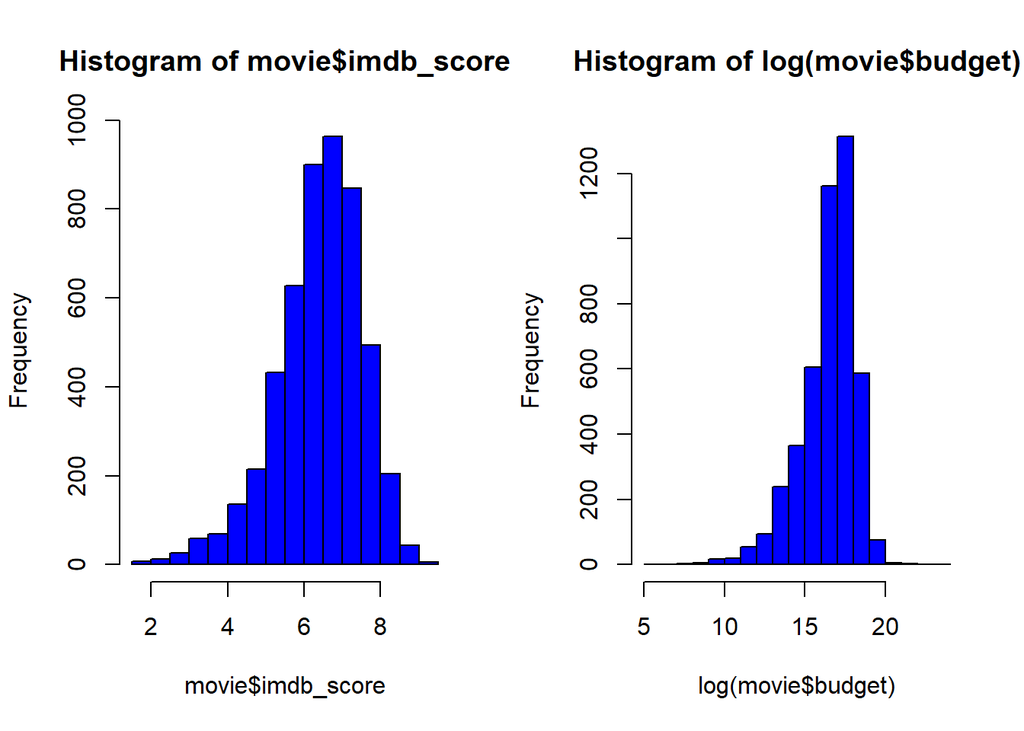

```r
# set display arrangement
par(mfrow=c(1,2))
# now we can draw two graphs in one window
hist(movie$imdb_score, col = "blue")
hist(log(movie$budget), col = "blue")
```

This only applies for R basic plot

## scatter plot of two variables

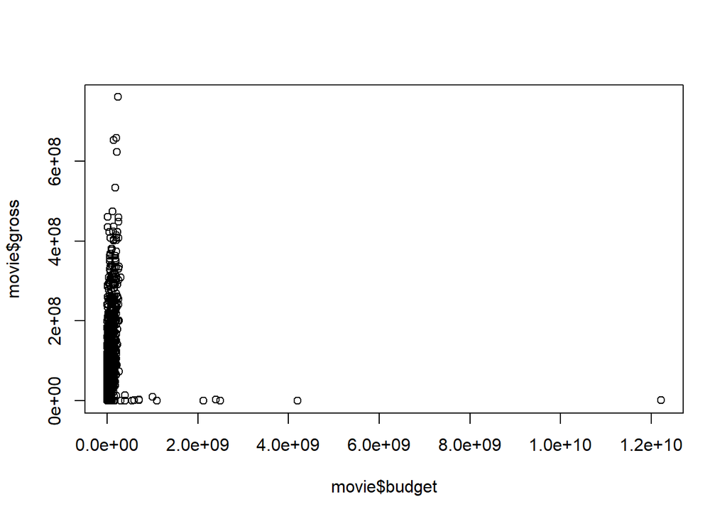

```r
plot(movie$budget, movie$gross)
```

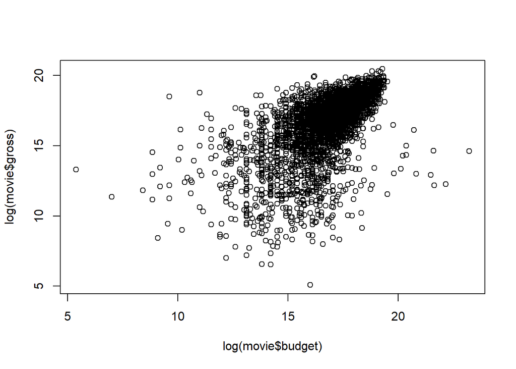

```r
plot(log(movie$budget), log(movie$gross))
```

## boxplot

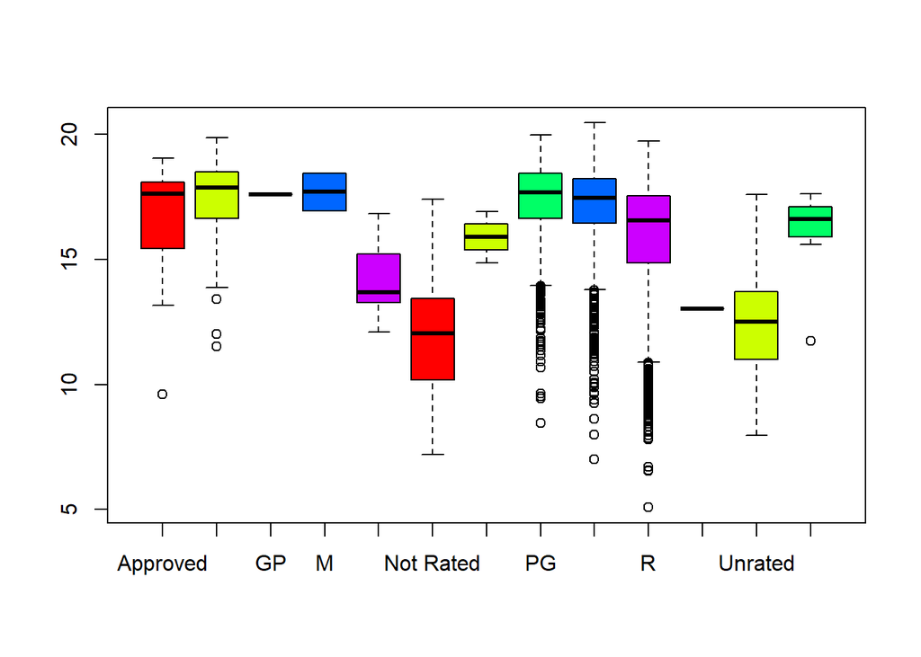

```r
boxplot(log(movie$gross)~movie$content_rating, col=rainbow(5))
```

#### exercise

1. get a histogram of duration, what can you tell?
2. get a scatter plot of log(budget) vs. imdb_score, what can you tell?

[Back to top](https://courseware.ku.edu/bbcswebdav/pid-7802891-dt-content-rid-35346974_1/courses/4199-24160/lab_eda2.html#top)

# ggplot

`ggplot` has its own syntax. It draws figure based on multiple layers.

## Histogram

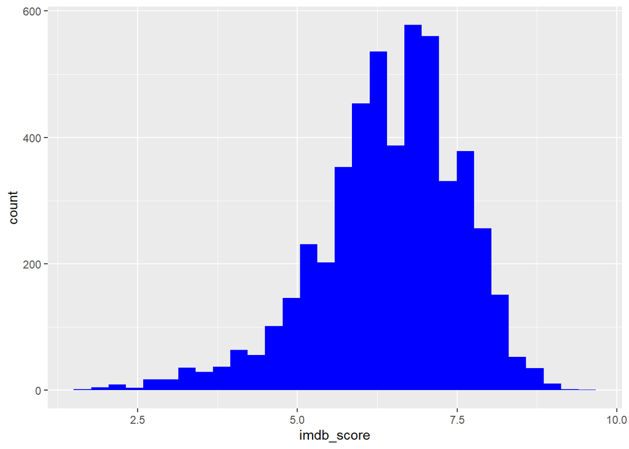

```r
ggplot(data=movie)+
  geom_histogram(mapping=aes(x=imdb_score), fill="blue")
```

The first function `ggplot(data=movie)` creates an empty plot, which is the first layer of you graph, just like you grab a white plain paper. Then, add another layer uning the function `geom_histogram()`. It stands for “geometric object - histogram”. Of course there are different types of geometric object, such as points, curves, straight lines, boxes, etc. You will see!

Each geom function in ggplot2 takes a `mapping` argument. This defines how variables in your dataset are mapped to visual properties. `aes` stands for aesthetic, which specifies what data you want to map (draw). Therefore, the `mapping` argument is always paired with `aes()`.

Here is a template to produce graphs using `ggplot2`

```r
ggplot(data = <DATA>) +
  <GEOM_FUNCTION>(mapping = aes(<MAPPINGS>))
```

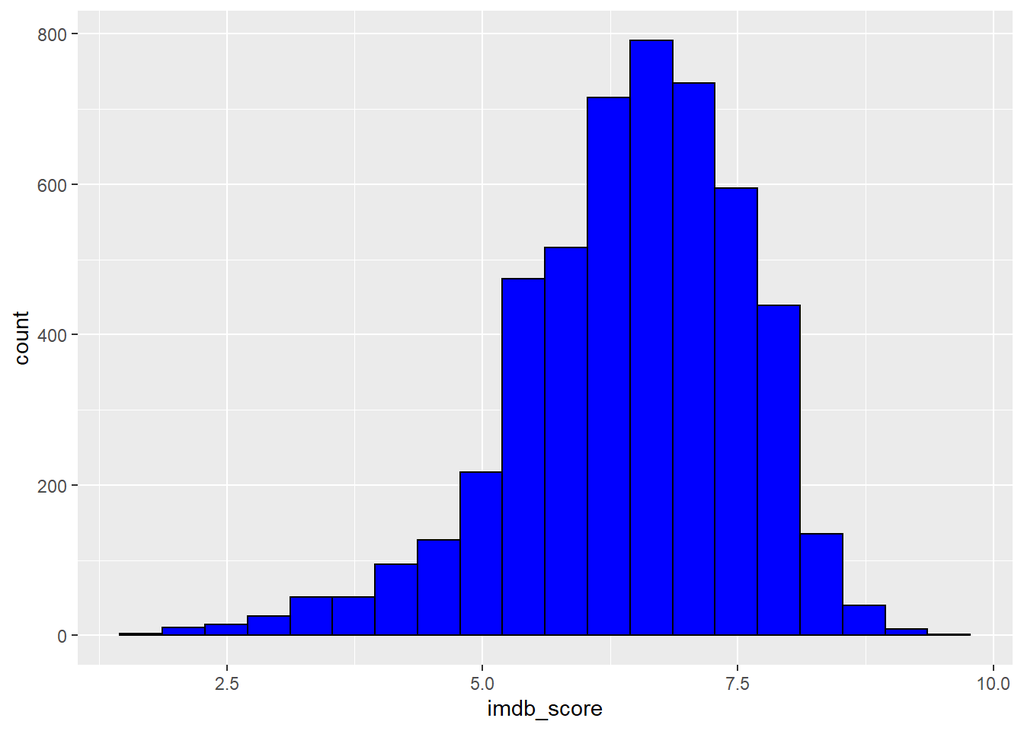

```r
ggplot(movie)+
  geom_histogram(aes(x=imdb_score), fill="blue", color="black", bins=20)
```

Note, it does not matter if you place the `mapping` in `ggplot()`. Then you only need to specify options in `geom_histogram()`.

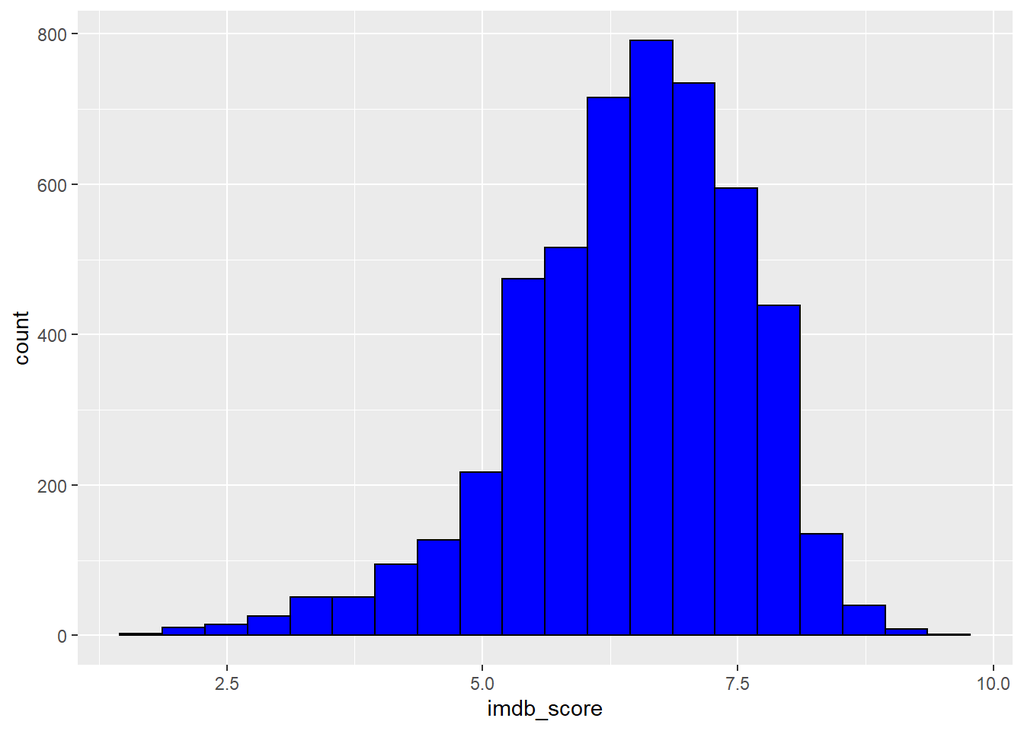

```r
ggplot(movie, aes(x=imdb_score))+
  geom_histogram(fill="blue", color="black", bins=20)
```

#### exercise:

Draw a histogram of log(budget), use green to fill and black as boundary.

## Scatter plot

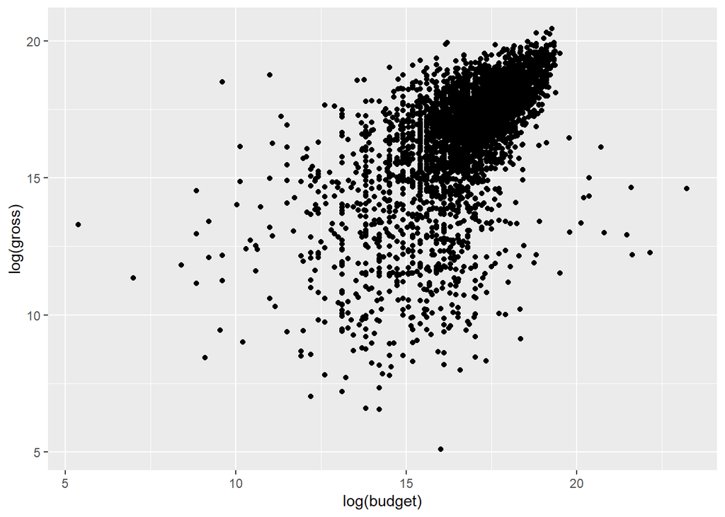

```r
ggplot(data=movie, aes(x=log(budget), y=log(gross)))+
  geom_point()
```

You can change the color, shape, and size of the dots.

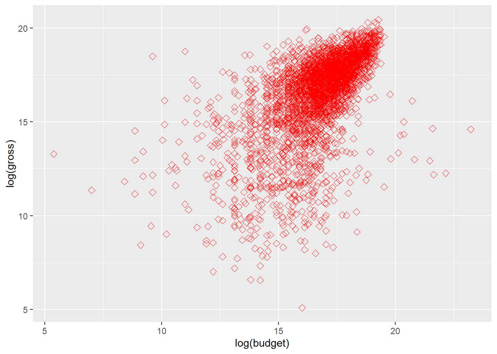

```r
ggplot(movie, aes(log(budget), log(gross)))+
  geom_point(color="red", shape=5, size=2)
```

### Show different groups

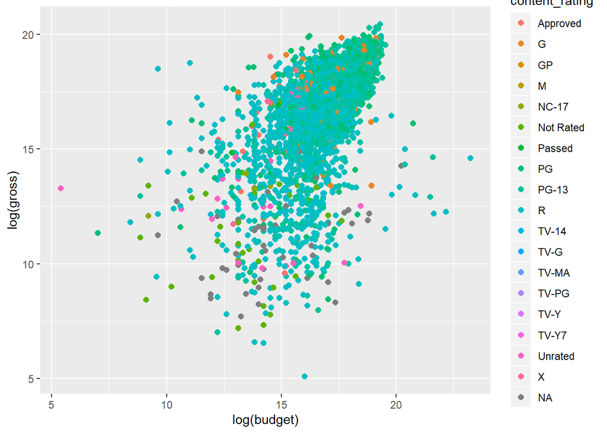

```r
ggplot(movie, aes(log(budget), log(gross), color=content_rating))+
  geom_point(size=2)
```

The `content_rating` is essentially the third dimension in this figure. That is why it has to be in `aes()`.

### Split to multiple figures by group

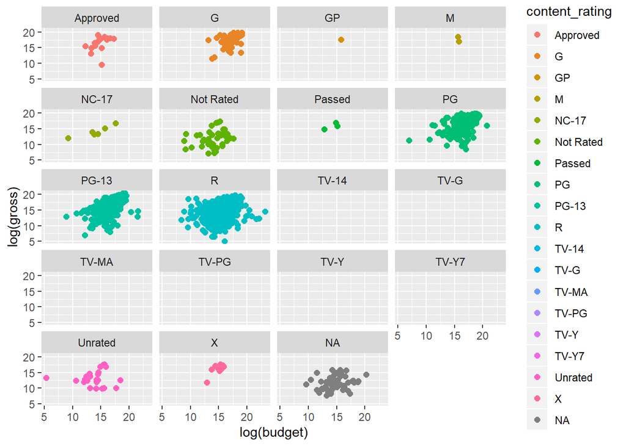

```r
ggplot(movie, aes(log(budget), log(gross), color=content_rating))+
  geom_point(size=2)+
  facet_wrap(~content_rating, nrow=5)
```

### Add another layer

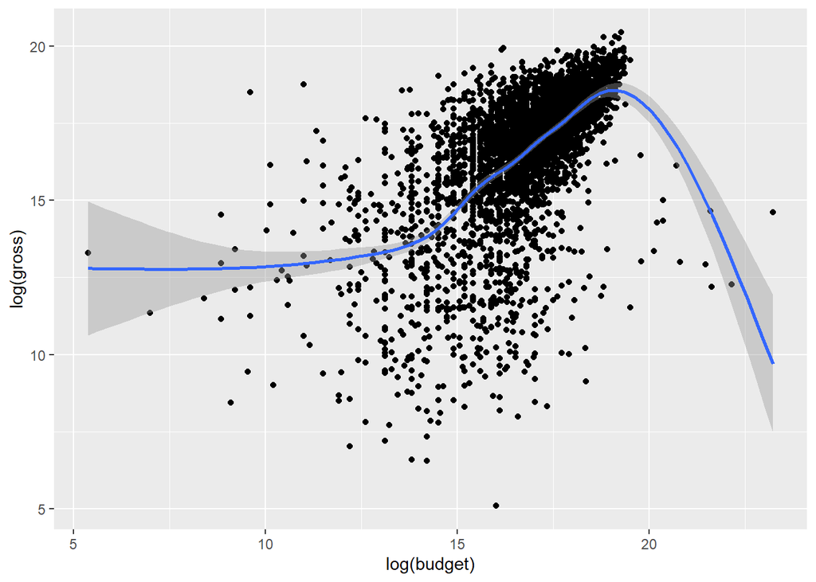

```r
ggplot(movie, aes(log(budget), log(gross)))+
  geom_point()+
  geom_smooth()
```

This adds a fitted smooth curve. You can also change it to a linear line.

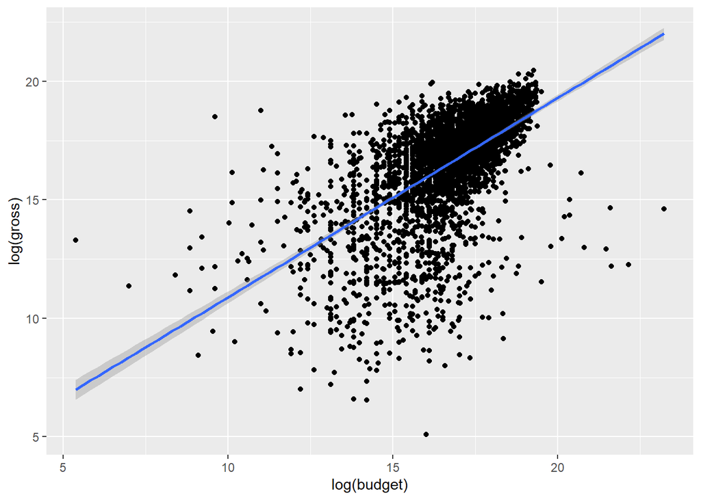

```r
ggplot(movie, aes(log(budget), log(gross)))+
  geom_point()+
  geom_smooth(method = "lm")
```

#### Exercise

1. Do you think higher budget implies higher imdb score? Investigate using scatter plot.
2. How does number of voted user relates to gross, budget, and imdb score?
3. Which content_ratings are the top 3? How does `log(budget)` distributed for each of them? How does number of voted user relates to imdb score for each of the 3 category?

## Boxplot

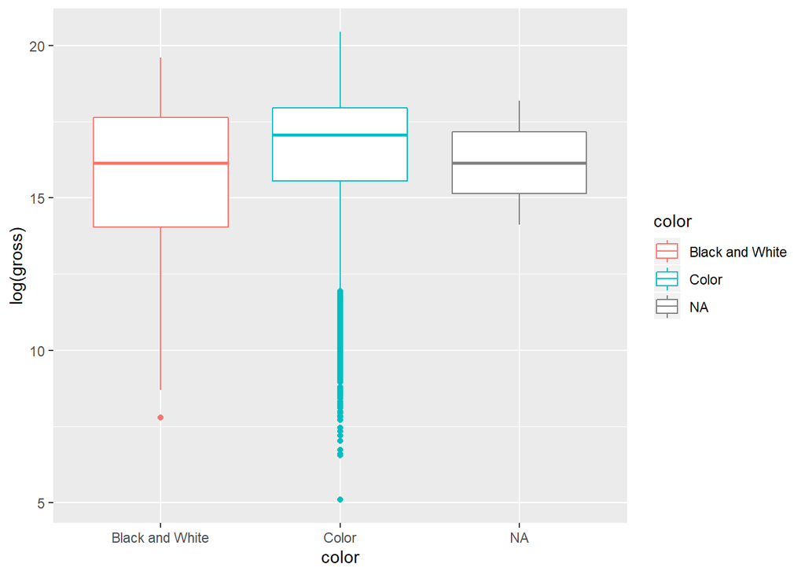

```r
ggplot(movie, aes(x=color, y=log(gross)))+
  geom_boxplot(aes(color=color))
```

You can directly apply functions like `filter()`, `select()` inside `ggplot`.

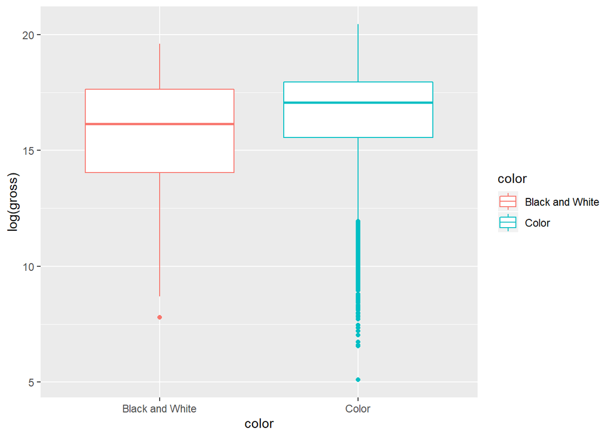

```r
ggplot(filter(movie, !is.na(color)), aes(x=color, y=log(gross)))+
  geom_boxplot(aes(color=color))
```

## Bar plot

Bar plot is like histogram, but it is for categorical variable. It is also very useful when compare certain statistic across different groups.

### Univariate bar plot

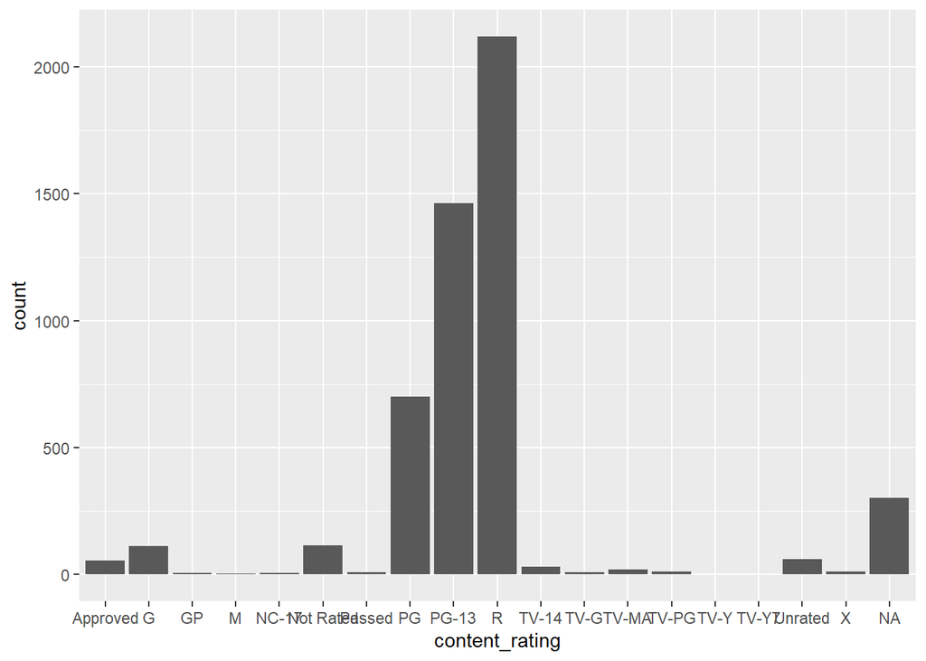

```r
ggplot(movie, aes(x=content_rating))+
  geom_bar()
```

We see the x label is not well displayed. We can make it vertical.

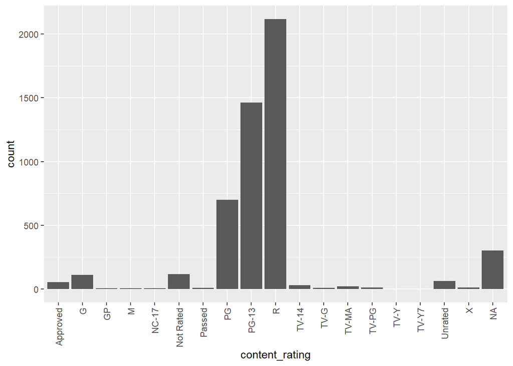

```r
ggplot(movie, aes(x=content_rating))+
  geom_bar()+
  theme(axis.text.x=element_text(angle=90,hjust=1,vjust=0.5))
```

Or we can flip the a-axis and y-axis.

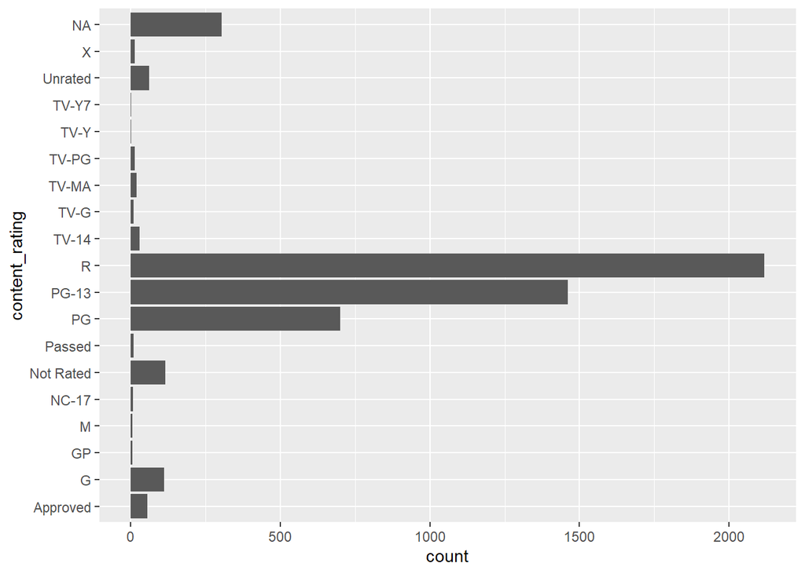

```r
ggplot(movie, aes(x=content_rating))+
  geom_bar()+
  coord_flip()
```

It might be more useful to show the proportion rather than count on y-axis.

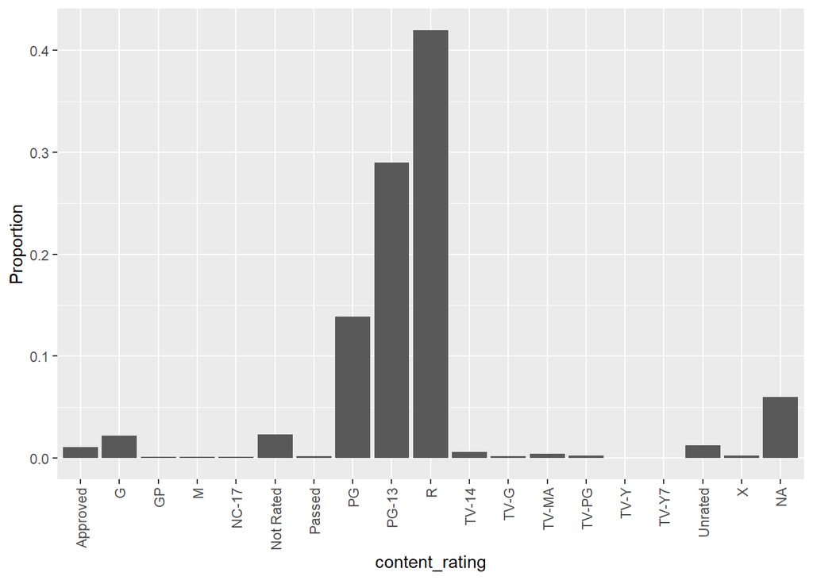

```r
ggplot(movie, aes(x=content_rating))+
  geom_bar(aes(y = (..count..)/sum(..count..)))+
  ylab("Proportion")+
  theme(axis.text.x=element_text(angle=90,hjust=1,vjust=0.5))
```

#### Exercise

Can you fill different color for those bars in above figure?

### Bar plot for multiple variables

Let us first create a new variable, which is categorized imdb score. Then we filter the 4 most popular content ratings.

```r
movie1<- movie %>%
  mutate(cate_score=cut(imdb_score, breaks=c(0, 4, 6, 7, 10), labels=c("poor", "okay", "good", "great"), include.lowest=T)) %>%
  filter(content_rating %in% c("R", "PG", "PG-13", "G"))
```

Do you think higher scored movies have higher `gross`? You may draw scatter plot to answer this question. But if one of the variables is categorical, such as the categorized imdb score, bar plot is a better choice.

However, you need first get the average gross for each category. It is essentially calculating some summary statistcs. Therefore, we use function `stat_summary()` instead of directly using `geom_bar()`. You can specify different `geom` in `stat_summary()`.

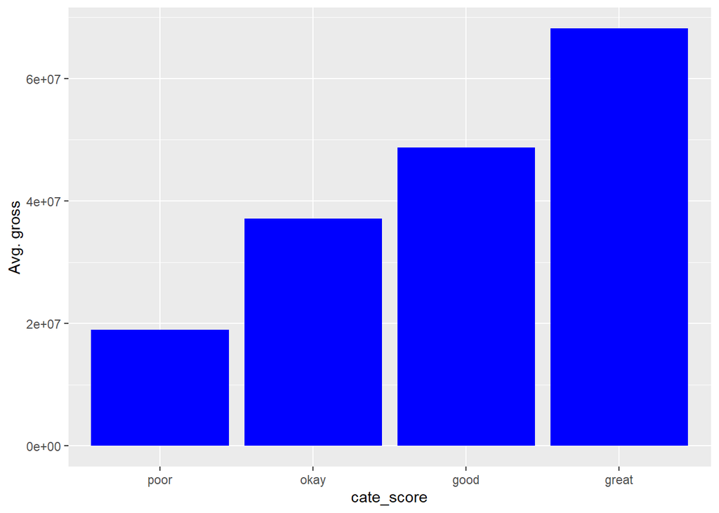

```r
ggplot(movie1, aes(x=cate_score, y=gross))+
  stat_summary(fun.y = "mean", geom="bar", fill="blue", na.rm = T)+
  ylab("Avg. gross")
```

Now what if you also want to look at different content ratings?

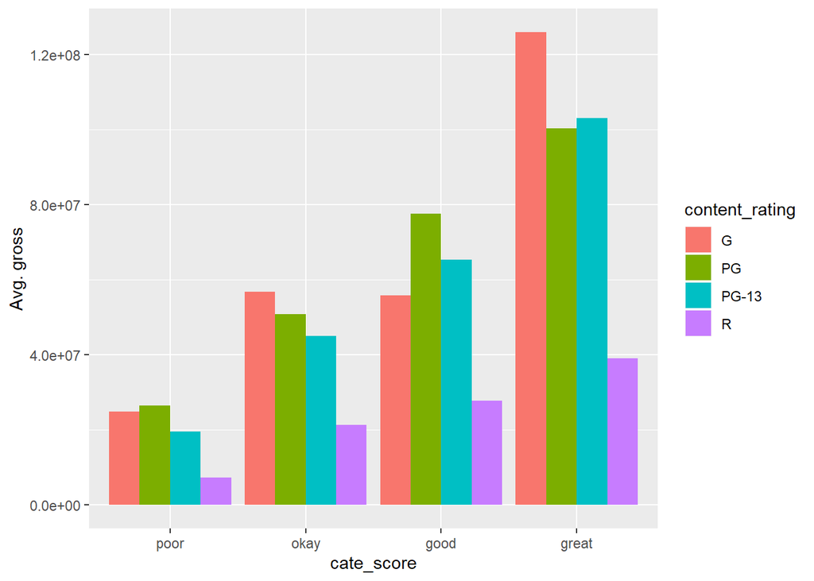

```r
ggplot(movie1, aes(x=cate_score, y=gross, fill= content_rating))+
  stat_summary(fun.y = "mean", geom="bar", na.rm = T, position = "dodge")+
  ylab("Avg. gross")
```

#### Exercise

1. In above figure, what do you get if you switch `cate_score` and `content_rating`?
2. Categorize title year to <=1980, 1981-2000, 2001-2005, >2005, then use bar chart to show the frequency.
3. What is average budget for each category of title year?
4. Can you show above bar plot for each content rating?

[Back to top](https://courseware.ku.edu/bbcswebdav/pid-7802891-dt-content-rid-35346974_1/courses/4199-24160/lab_eda2.html#top)

# Movie genres and bar plot

In this section we show how to handle variables like `genres`. Each movie has multiple genres, and they are separated by “|”. We know how to separate them into different columns in Excel. We now show how to work it out in R. We need another package `tm`, which was built for text mining.

### Create sparse matrix for genre

```r
library(tm)
genres<- (sapply(movie$genres,gsub,pattern="\\|",replacement=" "))
genre.sparse.mat <- DocumentTermMatrix(Corpus(VectorSource(genres)))
genre.sparse.mat<- as.matrix(genre.sparse.mat)
```

### Average score for each genre

```r
mat.score<- genre.sparse.mat*movie$imdb_score
apply(ifelse(mat.score==0, NA, mat.score), 2, median, na.rm=TRUE)
```

```
##      action   adventure     fantasy      sci-fi    thriller documentary
##        6.30        6.60        6.40        6.40        6.40        7.40
##     romance   animation      comedy      family     musical     mystery
##        6.50        6.70        6.30        6.40        6.70        6.60
##     western       drama     history       sport       crime      horror
##        6.80        6.90        7.20        6.80        6.60        5.90
##         war   biography       music   game-show  reality-tv        news
##        7.10        7.20        6.60        2.90        4.75        7.40
##       short   film-noir
##        6.50        7.65
```

### Bar plot

How to draw a bar plot for the numbers we got above? A more general question is: how to draw a bar plot given the summary statistics?

You will need to create new data frame with one column being the genre name and the other being the average scores.

```r
genre_score<- data.frame(genre=colnames(mat.score),
                         avg_imdb_score=apply(ifelse(mat.score==0, NA, mat.score), 2, median, na.rm=TRUE))
```

Then draw the bar chart.

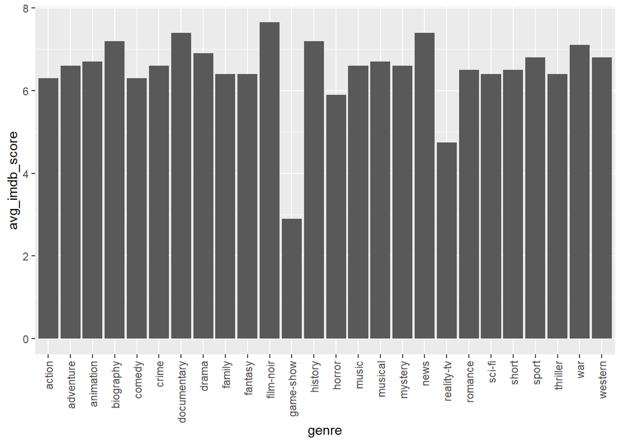

```r
ggplot(genre_score, aes(x=genre, y=avg_imdb_score))+
  geom_bar(stat="identity")+
  theme(axis.text.x=element_text(angle=90,hjust=1,vjust=0.5))
```

`stat="identity"` means it directly plot the values of y as the height of y-axis.

#### Exercise

Can you get the frequency (count) instead of average score as the y-axis?

[Back to top](https://courseware.ku.edu/bbcswebdav/pid-7802891-dt-content-rid-35346974_1/courses/4199-24160/lab_eda2.html#top)